# Practical Machine Learning PA

Anton Lukyanov

Sunday, January 25, 2015

#### Executive Summary

Main topic of this letter is Human Activity Recognition (HAR) problem. Research based on Weight Lifting Exercise Dataset. The data is collected from accelerometers on the arm, forearm, belt and dumbell of 6 participants.The data come from this source: http://groupware.les.inf.puc-rio.br/har

This is a Practical Machine Learning Peer Assessment for Data Science Specialization from Coursera and John Hopkins Bloomberg School of Public Health.

#### Study design

Before building ML model we should chose appropriate variables, in other words clean data from the variables with significant share of `NAs` or near zero covariates. Next we should chose ML algorithm - in this study we will use Random Forest. We will povide the characteristics of the model, such as accuracy, which will evaluate the quality of the predictions.

##### Preparation

```r
library(caret)
library(randomForest)
set.seed(1982)
```

##### Load Data

```r
URLtrain <- "https://d396qusza40orc.cloudfront.net/predmachlearn/pml-training.csv"
URLtest <- "https://d396qusza40orc.cloudfront.net/predmachlearn/pml-testing.csv"
filenameTrain <- "pml-training.csv"
filenameTest <- "pml-testing.csv"
download.file(url=URLtrain, destfile=filenameTrain,method="curl")
download.file(url=URLtest, destfile=filenameTest,method="curl")
```

```r
training <- read.csv("pml-training.csv",row.names=1,na.strings = "")
testing <- read.csv("pml-testing.csv",row.names=1,na.strings = "NA")
```

##### Data Cleaning

To reduce number of variables we:

- remove near zero covariates,
- remove variables with missing values,
- remove columns with extra information such as ‘name’, ‘timestamp’ and so forth.

```r
#Remove near zero covariates
nzc <- nearZeroVar(training,saveMetrics=TRUE)
training <- training[,!nzc$nzv]
testing <- testing[,!nzc$nzv]

#Remove NAs
training_noNA <- training[,(colSums(is.na(training)) == 0)]
testing_noNA <- testing[,(colSums(is.na(testing)) == 0)]

#Remove names and timestamps
colTrain <- c("user_name","raw_timestamp_part_1","raw_timestamp_part_2","cvtd_timestamp","num_window")
colTest <- c("user_name","raw_timestamp_part_1","raw_timestamp_part_2","cvtd_timestamp","num_window","problem_id")
training_noCol <- training_noNA[,!(names(training_noNA) %in% colTrain)]
testing_noCol <- testing_noNA[,!(names(testing_noNA) %in% colTest)]

inTrain <- createDataPartition(y=training$classe, p=0.7, list=FALSE)
training_clean <- training_noCol[inTrain,]
validation_clean <- training_noCol[-inTrain,]
```

New set contain 52 predictors.

##### Random Forest

```r
#Fit model
Fit <- train(classe ~ ., method = "rf", data = training_clean, importance = T, trControl = trainControl(method = "cv", number = 4))
#Validate
validation_pred <- predict(Fit, newdata=validation_clean)
#Confusion Matrix and Accuracy
confusionMatrix(validation_pred,validation_clean$classe)
```

```
## Confusion Matrix and Statistics
##
##           Reference
## Prediction    A    B    C    D    E
##          A 1671    9    0    0    0
##          B    3 1128    6    0    0
##          C    0    2 1014   11    2
##          D    0    0    6  952    6
##          E    0    0    0    1 1074
##
## Overall Statistics
##
##                Accuracy : 0.9922
##                  95% CI : (0.9896, 0.9943)
##     No Information Rate : 0.2845
##     P-Value [Acc > NIR] : < 2.2e-16
##
##                   Kappa : 0.9901
##  Mcnemar's Test P-Value : NA
##
## Statistics by Class:
##
##                      Class: A Class: B Class: C Class: D Class: E
## Sensitivity            0.9982   0.9903   0.9883   0.9876   0.9926
## Specificity            0.9979   0.9981   0.9969   0.9976   0.9998
## Pos Pred Value         0.9946   0.9921   0.9854   0.9876   0.9991
## Neg Pred Value         0.9993   0.9977   0.9975   0.9976   0.9983
## Prevalence             0.2845   0.1935   0.1743   0.1638   0.1839
## Detection Rate         0.2839   0.1917   0.1723   0.1618   0.1825
## Detection Prevalence   0.2855   0.1932   0.1749   0.1638   0.1827
## Balanced Accuracy      0.9980   0.9942   0.9926   0.9926   0.9962
```

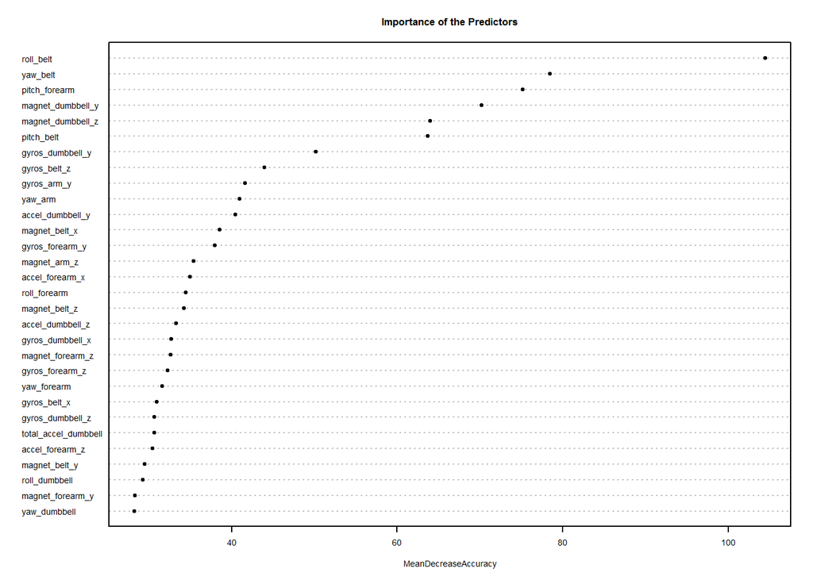

```r
#Importance of variables
imp <- varImp(Fit)$importance
varImpPlot(Fit$finalModel, sort = TRUE, type = 1, pch = 19, col = 1, cex = 0.45, main = "Importance of the Predictors")
```

##### Conclusion

We build model based on the Random Forest algorithm with the Accuracy 0.99. Also we can highlight the most imporatnt variables for the prediction of HAR from the plot above.

##### Appendix. Prediction for the Submission part of PA.

```r
testing_pred <- predict(Fit, newdata=testing_noCol)
write_files <- function(x) {
        n <- length(x)
        for (i in 1:n) {
                filename <- paste0("problem_id", i, ".txt")
                write.table(x[i], file=filename, quote=FALSE, row.names=FALSE,col.names=FALSE)
        }
}
write_files(testing_pred)
```